# CWM_Models

Maggie Klope

## GLMs for Community-weighted means (CWMs)

- Calculated with 2017 trait data
- Only one block sampled at each climate/treatment, so no blocking effect.

### Models:

**What is the effect of climate and grazing on community-weighted means?**

**Is there an interaction between climate and grazing?**

`glm(LA ~ Climate * Treatment, family = gaussian)`

#### a. LA CWM

- Averaged over treatment, climate is different between Arid-Int and Arid-Mesic
- Averaged over climate, treatment is different between Open-Total and Partial-Total, but not Open-Partial
- Arid Total LA CWM larger than all other plots
- Arid:
  - Arid Total > Arid Open and Arid Partial
  - No difference between Arid Open and Arid Partial
- Intermediate:
  - No difference between herbivore treatments
- Mesic:
  - No difference between herbivore treatments
- Total herbivore treatment:
  - Arid Total larger than Intermediate Total and Mesic Total
  - No difference between Int Total and Mesic Total
- No differences between Open or Partial Treatments across climates

```r
# Best fit model:
LA_CWM <- glm(data = cwm_traits_adj, weighted_la ~ climate * treatment, family = gaussian, na.action = na.fail)
dredge(LA_CWM) #best model: weighted_la ~ climate * treatment
```

```
## Fixed term is "(Intercept)"
```

```
## Global model call: glm(formula = weighted_la ~ climate * treatment, family = gaussian,
##     data = cwm_traits_adj, na.action = na.fail)
## ---
## Model selection table
##   (Int) clm trt clm:trt df   logLik  AICc delta weight
## 8 25.74   +   +       + 10  -87.924 209.6  0.00      1
## 2 45.97   +              4 -111.244 232.3 22.71      0
## 4 38.86   +   +          6 -108.753 233.7 24.11      0
## 1 31.46                  2 -116.518 237.5 27.94      0
## 3 24.35       +          4 -114.884 239.6 29.99      0
## Models ranked by AICc(x)
```

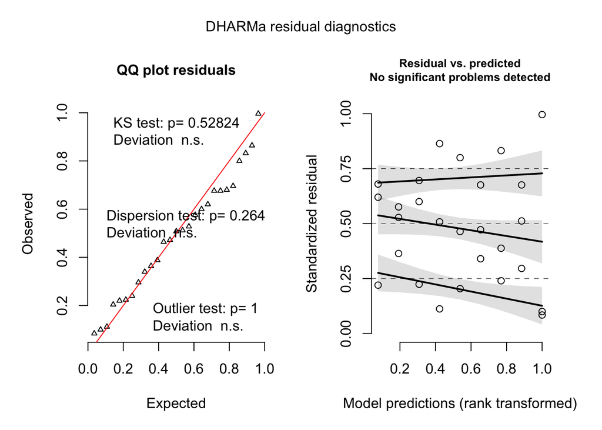

```
## Object of Class DHARMa with simulated residuals based on 250 simulations with refit = FALSE . See ?DHARMa::simulateResiduals for help.
##
## Scaled residual values: 0.224 0.6 0.696 0.296 0.676 0.512 0.1 0.996 0.084 0.528 0.364 0.576 0.464 0.8 0.204 0.508 0.112 0.864 0.388 0.832 ...
```

```r
# Checking data
simulateResiduals(LA_CWM, plot = T) #What is the red asterisk on the model predictions graph?
```

```r
shapiro.test(residuals(LA_CWM)) #normal
```

```
##
##  Shapiro-Wilk normality test
##
## data:  residuals(LA_CWM)
## W = 0.94943, p-value = 0.2076
```

```r
# pairwise comparisons
emmeans(LA_CWM, pairwise ~ climate)
```

```
## NOTE: Results may be misleading due to involvement in interactions
```

```
## $emmeans
##  climate      emmean   SE  df asymp.LCL asymp.UCL
##  Arid           46.0 2.56 Inf      40.9      51.0
##  Intermediate   23.1 2.56 Inf      18.1      28.1
##  Mesic          25.3 2.56 Inf      20.3      30.3
##
## Results are averaged over the levels of: treatment
## Confidence level used: 0.95
##
## $contrasts
##  contrast             estimate   SE  df z.ratio p.value
##  Arid - Intermediate     22.85 3.63 Inf  6.300  <.0001
##  Arid - Mesic            20.69 3.63 Inf  5.705  <.0001
##  Intermediate - Mesic    -2.16 3.63 Inf -0.596  0.8224
##
## Results are averaged over the levels of: treatment
## P value adjustment: tukey method for comparing a family of 3 estimates
```

```r
emmeans(LA_CWM, pairwise ~ treatment)
```

```
## NOTE: Results may be misleading due to involvement in interactions
```

```
## $emmeans
##  treatment emmean   SE  df asymp.LCL asymp.UCL
##  Open        24.4 2.56 Inf      19.3      29.4
##  Partial     30.7 2.56 Inf      25.7      35.8
##  Total       39.3 2.56 Inf      34.3      44.3
##
## Results are averaged over the levels of: climate
## Confidence level used: 0.95
##
## $contrasts
##  contrast        estimate   SE  df z.ratio p.value
##  Open - Partial     -6.38 3.63 Inf -1.761  0.1830
##  Open - Total      -14.93 3.63 Inf -4.116  0.0001
##  Partial - Total    -8.54 3.63 Inf -2.356  0.0485
##
## Results are averaged over the levels of: climate
## P value adjustment: tukey method for comparing a family of 3 estimates
```

```r
emmeans(LA_CWM, pairwise ~ climate * treatment)
```

```
## $emmeans
##  climate      treatment emmean   SE  df asymp.LCL asymp.UCL
##  Arid         Open        25.7 4.44 Inf     17.03      34.4
##  Intermediate Open        15.8 4.44 Inf      7.10      24.5
##  Mesic        Open        31.5 4.44 Inf     22.81      40.2
##  Arid         Partial     36.1 4.44 Inf     27.37      44.8
##  Intermediate Partial     27.3 4.44 Inf     18.59      36.0
##  Mesic        Partial     28.8 4.44 Inf     20.13      37.5
##  Arid         Total       76.1 4.44 Inf     67.38      84.8
##  Intermediate Total       26.3 4.44 Inf     17.55      35.0
##  Mesic        Total       15.5 4.44 Inf      6.79      24.2
##
## Confidence level used: 0.95
##
## $contrasts
##  contrast                                  estimate   SE  df z.ratio p.value
##  Arid,Open - Intermediate,Open                9.929 6.28 Inf  1.581  0.8156
##  Arid,Open - Mesic,Open                      -5.779 6.28 Inf -0.920  0.9919
##  Arid,Open - Arid,Partial                   -10.342 6.28 Inf -1.647  0.7789
##  Arid,Open - Intermediate,Partial            -1.562 6.28 Inf -0.249  1.0000
##  Arid,Open - Mesic,Partial                   -3.098 6.28 Inf -0.493  0.9999
##  Arid,Open - Arid,Total                     -50.353 6.28 Inf -8.017  <.0001
##  Arid,Open - Intermediate,Total              -0.520 6.28 Inf -0.083  1.0000
##  Arid,Open - Mesic,Total                     10.242 6.28 Inf  1.631  0.7880
##  Intermediate,Open - Mesic,Open             -15.708 6.28 Inf -2.501  0.2313
##  Intermediate,Open - Arid,Partial           -20.271 6.28 Inf -3.227  0.0340
##  Intermediate,Open - Intermediate,Partial   -11.491 6.28 Inf -1.829  0.6624
##  Intermediate,Open - Mesic,Partial          -13.027 6.28 Inf -2.074  0.4912
##  Intermediate,Open - Arid,Total             -60.282 6.28 Inf -9.598  <.0001
##  Intermediate,Open - Intermediate,Total     -10.448 6.28 Inf -1.664  0.7689
##  Intermediate,Open - Mesic,Total              0.314 6.28 Inf  0.050  1.0000
##  Mesic,Open - Arid,Partial                   -4.563 6.28 Inf -0.727  0.9984
##  Mesic,Open - Intermediate,Partial            4.217 6.28 Inf  0.671  0.9991
##  Mesic,Open - Mesic,Partial                   2.680 6.28 Inf  0.427  1.0000
##  Mesic,Open - Arid,Total                    -44.574 6.28 Inf -7.097  <.0001
##  Mesic,Open - Intermediate,Total              5.259 6.28 Inf  0.837  0.9957
##  Mesic,Open - Mesic,Total                    16.021 6.28 Inf  2.551  0.2079
##  Arid,Partial - Intermediate,Partial          8.780 6.28 Inf  1.398  0.8990
##  Arid,Partial - Mesic,Partial                 7.244 6.28 Inf  1.153  0.9658
##  Arid,Partial - Arid,Total                  -40.011 6.28 Inf -6.370  <.0001
##  Arid,Partial - Intermediate,Total            9.823 6.28 Inf  1.564  0.8245
##  Arid,Partial - Mesic,Total                  20.584 6.28 Inf  3.277  0.0291
##  Intermediate,Partial - Mesic,Partial        -1.536 6.28 Inf -0.245  1.0000
##  Intermediate,Partial - Arid,Total          -48.791 6.28 Inf -7.768  <.0001
##  Intermediate,Partial - Intermediate,Total    1.042 6.28 Inf  0.166  1.0000
##  Intermediate,Partial - Mesic,Total          11.804 6.28 Inf  1.879  0.6281
##  Mesic,Partial - Arid,Total                 -47.255 6.28 Inf -7.524  <.0001
##  Mesic,Partial - Intermediate,Total           2.579 6.28 Inf  0.411  1.0000
##  Mesic,Partial - Mesic,Total                 13.341 6.28 Inf  2.124  0.4567
##  Arid,Total - Intermediate,Total             49.833 6.28 Inf  7.934  <.0001
##  Arid,Total - Mesic,Total                    60.595 6.28 Inf  9.648  <.0001
##  Intermediate,Total - Mesic,Total            10.762 6.28 Inf  1.713  0.7385
##
## P value adjustment: tukey method for comparing a family of 9 estimates
```

```r
#visualization

# data <- as.data.frame(test$emmeans) %>%
#   mutate(upper_limit = emmean +  SE) %>%
#   mutate(lower_limit = emmean -  SE)
#
# ggplot(data, aes(x = climate, y = emmean)) +
#   geom_point()+
#   facet_wrap(data$treatment)+
# # geom_ribbon(aes(ymin = data$lower_limit, ymax = data$upper_limit), linetype=2, alpha=0.1)
# # geom_errorbar(aes(ymin = data$lower_limit, ymax = data$upper_limit)
#   geom_pointrange(aes(ymin = data$lower_limit, ymax = data$upper_limit))
#

# plot(pairs(emmeans(LA_CWM, ~ climate | treatment)), comparisons = TRUE)

# plot(emmeans(LA_CWM, ~ climate * treatment),
#      type = "response",
#      comparisons = TRUE, # If arrows overlap, they are not statistically significant
#      colors = c("black", "black", "blue", "black")) + # color names for estimates, CIs, PIs, and comparison arrows, respectively
#   # this is a ggplot so you can customize as normal
#   theme_bw() +
#   labs(x = "Estimated marginal mean (LA CWM)", y = "Climate")

#Compact Letter Display
la_emm <- emmeans(LA_CWM, ~ climate)
```

```
## NOTE: Results may be misleading due to involvement in interactions
```

```r
la_cdf <- multcomp::cld(la_emm, alpha = 0.05, Letters = LETTERS)

# pretty_table <- la_data_1 %>%
#   as_tibble() %>%
#   gt(rowname_col = "contrast", groupname_col = "functional_group") %>%
#   tab_header(
#     title = "Climate by Functional Group") %>%
#   fmt_number("p.value", decimal = 4) %>%
#   tab_style(
#     style = cell_text(weight = "bold"),
#     locations = cells_body(
#       columns = vars(p.value),
#       rows = p.value <= 0.05)
#   )
```

##### i. double-checking against ANOVA results

```r
# double-checking against anova results
LA_aov <- aov(data = cwm_traits_adj, weighted_la ~ climate * treatment)

dredge(LA_aov)
```

```
## Fixed term is "(Intercept)"
```

```
## Global model call: aov(formula = weighted_la ~ climate * treatment, data = cwm_traits_adj)
## ---
## Model selection table
##   (Int) clm trt clm:trt df   logLik  AICc delta weight
## 8 25.74   +   +       + 10  -87.924 209.6  0.00      1
## 2 45.97   +              4 -111.244 232.3 22.71      0
## 4 38.86   +   +          6 -108.753 233.7 24.11      0
## 1 31.46                  2 -116.518 237.5 27.94      0
## 3 24.35       +          4 -114.884 239.6 29.99      0
## Models ranked by AICc(x)
```

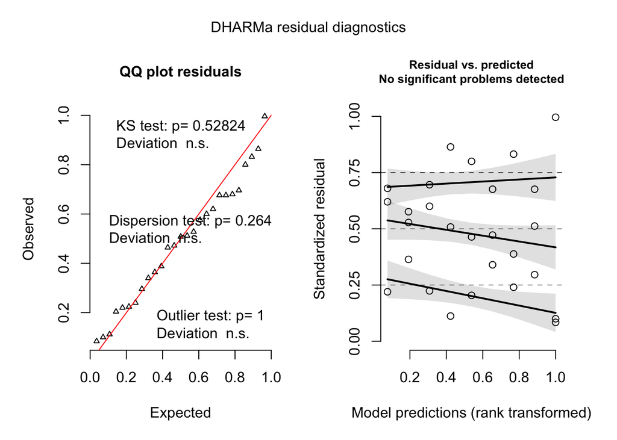

```
## Object of Class DHARMa with simulated residuals based on 250 simulations with refit = FALSE . See ?DHARMa::simulateResiduals for help.
##
## Scaled residual values: 0.224 0.6 0.696 0.296 0.676 0.512 0.1 0.996 0.084 0.528 0.364 0.576 0.464 0.8 0.204 0.508 0.112 0.864 0.388 0.832 ...
```

```r
simulateResiduals(LA_aov, plot = T)
```

```r
shapiro.test(residuals(LA_aov))
```

```
##
##  Shapiro-Wilk normality test
##
## data:  residuals(LA_aov)
## W = 0.94943, p-value = 0.2076
```

```r
summary(LA_aov)
```

```
##                   Df Sum Sq Mean Sq F value   Pr(>F)
## climate            2   2864  1431.9  24.198 7.91e-06 ***
## treatment          2   1010   504.8   8.531  0.00248 **
## climate:treatment  4   3918   979.4  16.552 7.53e-06 ***
## Residuals         18   1065    59.2
## ---
## Signif. codes:  0 '***' 0.001 '**' 0.01 '*' 0.05 '.' 0.1 ' ' 1
```

```r
tukey_LA <- TukeyHSD(LA_aov)
TukeyHSD(LA_aov)
```

```
##   Tukey multiple comparisons of means
##     95% family-wise confidence level
##
## Fit: aov(formula = weighted_la ~ climate * treatment, data = cwm_traits_adj)
##
## $climate
##                         diff        lwr       upr     p adj
## Intermediate-Arid  -22.84743 -32.102318 -13.59253 0.0000175
## Mesic-Arid         -20.68678 -29.941668 -11.43188 0.0000590
## Mesic-Intermediate   2.16065  -7.094243  11.41554 0.8240905
##
## $treatment
##                    diff        lwr      upr     p adj
## Partial-Open   6.384216 -2.8706766 15.63911 0.2109456
## Total-Open    14.926819  5.6719263 24.18171 0.0017847
## Total-Partial  8.542603 -0.7122898 17.79750 0.0733237
##
## $`climate:treatment`
##                                                diff        lwr        upr
## Intermediate:Open-Arid:Open              -9.9286732 -31.936167  12.078820
## Mesic:Open-Arid:Open                      5.7788978 -16.228596  27.786391
## Arid:Partial-Arid:Open                   10.3423135 -11.665180  32.349807
## Intermediate:Partial-Arid:Open            1.5621467 -20.445347  23.569640
## Mesic:Partial-Arid:Open                   3.0984126 -18.909081  25.105906
## Arid:Total-Arid:Open                     50.3531475  28.345654  72.360641
## Intermediate:Total-Arid:Open              0.5197107 -21.487783  22.527204
## Mesic:Total-Arid:Open                   -10.2421766 -32.249670  11.765317
## Mesic:Open-Intermediate:Open             15.7075710  -6.299923  37.715065
## Arid:Partial-Intermediate:Open           20.2709867  -1.736507  42.278480
## Intermediate:Partial-Intermediate:Open   11.4908200 -10.516674  33.498314
## Mesic:Partial-Intermediate:Open          13.0270858  -8.980408  35.034579
## Arid:Total-Intermediate:Open             60.2818208  38.274327  82.289314
## Intermediate:Total-Intermediate:Open     10.4483839 -11.559110  32.455877
## Mesic:Total-Intermediate:Open            -0.3135033 -22.320997  21.693990
## Arid:Partial-Mesic:Open                   4.5634157 -17.444078  26.570909
## Intermediate:Partial-Mesic:Open          -4.2167511 -26.224245  17.790743
## Mesic:Partial-Mesic:Open                 -2.6804852 -24.687979  19.327008
## Arid:Total-Mesic:Open                    44.5742498  22.566756  66.581743
## Intermediate:Total-Mesic:Open            -5.2591871 -27.266681  16.748306
## Mesic:Total-Mesic:Open                  -16.0210744 -38.028568   5.986419
```

[output cut: 37 more lines]

```
## Intermediate:Partial-Arid:Partial       0.8846283
## Mesic:Partial-Arid:Partial              0.9567121
## Arid:Total-Arid:Partial                 0.0001477
## Intermediate:Total-Arid:Partial         0.8113853
## Mesic:Total-Arid:Partial                0.0773004
## Mesic:Partial-Intermediate:Partial      0.9999993
## Arid:Total-Intermediate:Partial         0.0000108
## Intermediate:Total-Intermediate:Partial 1.0000000
## Mesic:Total-Intermediate:Partial        0.6345011
## Arid:Total-Mesic:Partial                0.0000168
## Intermediate:Total-Mesic:Partial        0.9999630
## Mesic:Total-Mesic:Partial               0.4882451
## Intermediate:Total-Arid:Total           0.0000080
## Mesic:Total-Arid:Total                  0.0000005
## Mesic:Total-Intermediate:Total          0.7318593
```